# Getting started

Colin Gillespie

## Installing the package

The package lives on [github](https://github.com/csgillespie/voltagefit/) and can be installed using

```r
devtools::install_github("csgillespie/voltagefit")
```

and loaded in the usual way

```r
library("voltagefit")
```

To enable parallelisation, run

```r
library("doParallel")
registerDoParallel()
```

## Example data

The package contains some example data sets that can be accessed via

```r
data_dir = system.file("extdata/", package="voltagefit")
list.files(data_dir)
```

```
## [1] "3737.rds" "3757.rds" "3758.rds" "3759.rds" "4464.rds" "4465.rds"
```

| ID | Week |
| --- | --- |
| 3737 | 1 |
| 3757 | 1 |
| 3758 | 1 |
| 3759 | 1 |
| 4464 | 2 |
| 4465 | 2 |

## A single wafer

We can load a single wafer from the package via

```r
## This is just a data frame.
## I expect the data will come from a database
wafer_3737 = readRDS(file.path(data_dir, "3737.rds"))
```

To fit the model to a single wafer, we use `fit_wafer`

```r
fit_3737 = fit_wafer(wafer_3737, verbose=FALSE)
fit_3737
```

```
##          X1        X2        X3         X4        X5       cost   id
## 1 -5.001225 -14.48381 0.5180648 -0.7164989 -29.93370 0.01570222 3737
## 2 -1.499658 -51.76989 1.6192156 -0.9955259 -23.44999 0.15556456 3737
##   direction
## 1   Forward
## 2  Backward
```

## Multiple wafers

```r
data_dir = system.file("extdata/", package="voltagefit")
## In real life, pull data from a database
all_wafers = fit_all(data_dir, verbose=FALSE)
```

You can also view the parameters

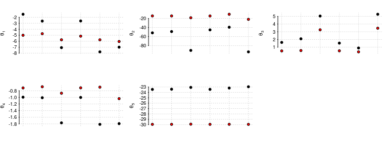

```r
plot(all_wafers)
```

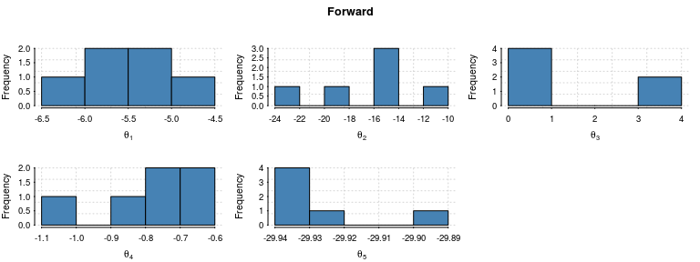

```r
hist(all_wafers)
```

## Design matrix

For each voltage curve, we have fitted a logistic model, obtained parameter estimates and estimated how well the curve fits. This next stage attempts to estimate week and treatment effects. Using the data in `all_wafers`, we first create a design matrix descriping the experimental set-up. The design matrix should have three columns

```r
wafer = unique(all_wafers$id)
week = c(1, 1, 1, 1, 2, 2)
treatment = rep(1, 6)
(design = data.frame(wafer = wafer, week = week, treatment = treatment))
```

```
##   wafer week treatment
## 1  3737    1         1
## 2  3757    1         1
## 3  3758    1         1
## 4  3759    1         1
## 5  4464    2         1
## 6  4465    2         1
```

We then fit a MANOVA model, using the parameter values as the response

```r
fit_man = fit_manova(all_wafers, design)
(params = get_params(fit_man))
```

```
##          X1        X2        X3         X4        X5     type direction
## 1 -5.428359 -13.11410 0.6999979 -0.7156207 -29.92670 baseline   Forward
## 2 -5.335683 -47.67723 1.6075762 -1.4622339 -23.28525 baseline  Backward
## 3 -5.085924 -15.08450 0.9151430 -0.7283230 -29.92866    week0   Forward
## 4 -5.770795 -11.14369 0.4848529 -0.7029183 -29.92473    week1   Forward
## 5 -2.921697 -54.38120 2.1923680 -1.1100925 -23.38537    week0  Backward
## 6 -7.749669 -40.97325 1.0227845 -1.8143753 -23.18513    week1  Backward
```

We can now get the mean parameters

```r
means = mean(fit_man)
```

and plot them

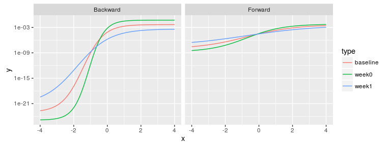

```r
library(ggplot2)
ggplot(means) + geom_line(aes(x, y, colour=type)) + scale_y_log10() +
  facet_grid(~direction)
```

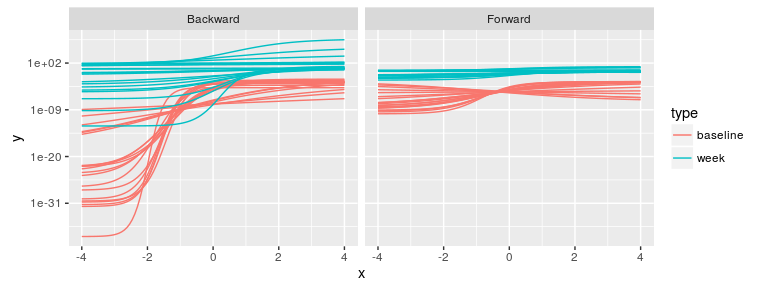

```r
## Generate a sample of parameters for the underlying curve
unders = sample(fit_man,  n=20)
#head(unders)

#unders = dd
ggplot(unders$samples) +
  geom_line(aes(x, y, group=sim_no, colour=type)) + scale_y_log10() +
  facet_grid(~direction)
```